# Modeling Gender Interests

# Introduction

We chose to investigate a “Young People Survey” data set. This data set has 150 variables representing answers to survey questions that were answered in both paper and electronic form. This survey was given to young Slovakian people between the ages of 15-30. The Survey asked them to give ratings to questions about different subjects pertinent to young people. The variables can be split into some distinct subsets as defined on Kaggle:

- Music preferences (19 items)
- Movie preferences (12 items)
- Hobbies & interests (32 items)
- Phobias (10 items)
- Health habits (3 items)
- Personality traits, views on life, & opinions (57 items)
- Spending habits (7 items)
- Demographics (10 items)

Answers to questions, for the most part, were recorded on a 5 point likert scale. In this analysis we aimed to pinpoint a few variables that contribute most, to predicting the gender variable, using the Hobbies & interests subset. In all models presented in this paper, we predict the female gender in the dataset. Models were fitted and evaluated with the caret package. Throughout our modeling process we estimated test error with 10 fold cross validation and then evaluated test error on a held out test set containing 20% of the data. We predefined fold indexes to avoid leakage, this was the main reason we used caret.

[output not shown]

# Modeling set up and EDA

This piece here is very important.  
* I first divide my data into a training and test set. We want to be able to evalutate the true test error rate of the model. We are not able to do this if we evaluate the model performance on data that was used to train it. * The data will be split into a 80% training set and a 20% testing set. * In order for our cross-valadation results to be valid, we need to make sure that we everalutate models on the same folds.

```r
split = round(nrow(youngPeople) * .80)
train = youngPeople[1:split, ]
test = youngPeople[(split + 1):nrow(youngPeople), ]
interests = train %>% select(Gender,History:Pets) %>% filter(Gender != "") %>% drop_na() %>% mutate(Gender = as.factor(Gender))
interestsTest = test %>% select(Gender,History:Pets) %>% filter(Gender != "") %>% drop_na() %>% mutate(Gender = as.factor(Gender))
```

## Variable selection:

In order to select variables for our models, we used two different methods, best subset regression and principal component analysis.

#### PCA:

Principal component analysis is a technique used for dimensionality redecution. I really like this definition from Abbas Keshvani: https://coolstatsblog.com/author/mabbask/

- “Principal Component Analysis, or PCA, is a statistical method used to reduce the number of variables in a dataset. It does so by lumping highly correlated variables together. Naturally, this comes at the expense of accuracy. However, if you have 50 variables and realize that 40 of them are highly correlated, you will gladly trade a little accuracy for simplicity.”

Principal component analysis was how we eventaully decided on the interestes subset of this dataset. We modeled the principal component analysis in many different subsets and found this one most interesting.

In the following figure, factor loadings are colored by the Gender of the observation. Principal component analysis is an unsupervised learning technqiue, which means that it does NOT use these Gender labels when reducing dimensions.

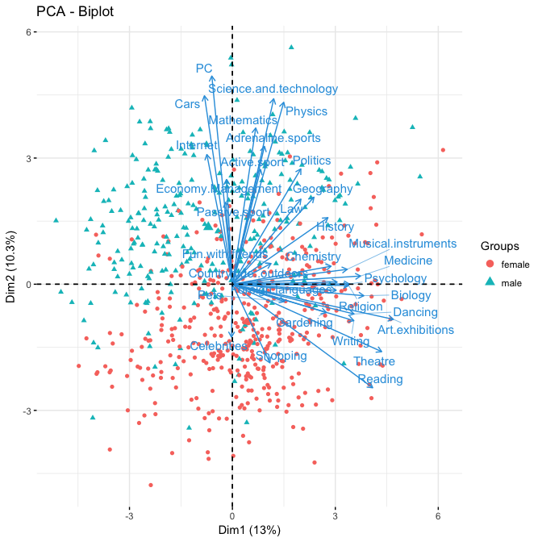

#### Best Subset Regression

In this course we studied the great book *Introduction to Statistical Learning with Applications in R* by Gareth et al. The book spends a good chunk on this method of variable selection. Personally, it is not my favorite method. We have come up with cross valaidation, regularization and many other ways to better handle this problem. We will use this in exploratory models to develop an inital hypothesis. While exploring we tried both forward and backward selection. Results were similar, so we decided to simply use forward selection.

This first figure will not include the nvmax argument to regsubsets(). This argument selects the maximum subsets to examine. The deault for this argument 8.

```r
library(leaps)
regfit <- regsubsets(Gender ~ ., interests, method = "forward")
```

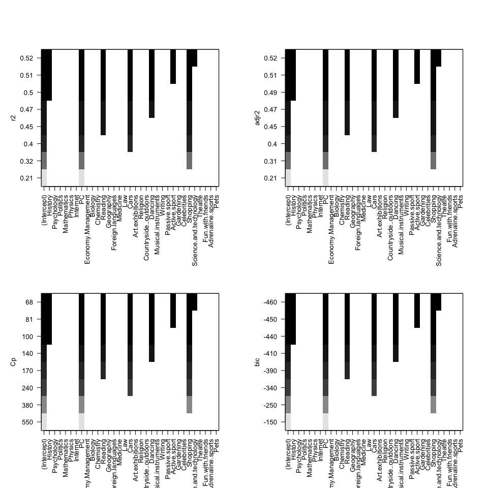

I next use the settings reccomended by ISLR, setting nvmax equal to the number of variables.

```r
library(leaps)
regfit2 <- regsubsets(Gender ~ ., interests, method = "forward", nvmax = 33)
```

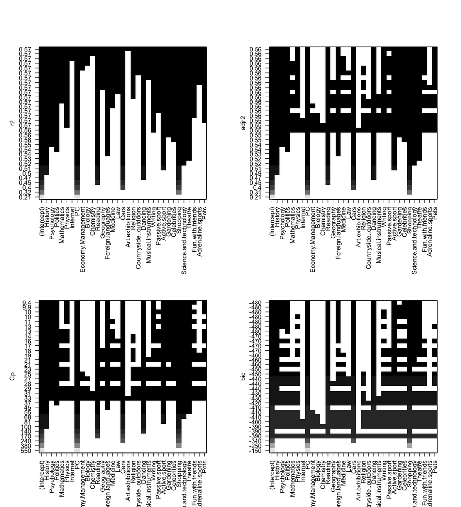

## Modeling

for creating statistical models we decided to use the caret packaage. It provides a variaty of tools to help us access both crossvalidation and test error.

I next createa a train control for all of the models. This allows us to use the same folds and crossvalidation methods across models.

```r
myFolds <- createFolds(interests$Gender, k = 10)
set.seed(2017)
myControl <- trainControl(
  method = "cv",
  number = 10,
  summaryFunction = twoClassSummary,
  classProbs = TRUE, # IMPORTANT!
  index = myFolds

)
pred = function(model){
preds = predict(model, interestsTest)
confusionMatrix(interestsTest$Gender, preds)}
```

#### Initial model: Logistic Regression

We fit an initial logistic regression with variables selected as important by both our stepwise selection and PCA. This model performs alright, but their is a big issue with this model.

```r
logreg<- train(Gender ~ PC + Reading + Cars + Shopping, interests, method = 'glm',
              trControl = myControl)
```

```
The metric "Accuracy" was not in the result set. ROC will be used instead.
```

```r
pred(logreg)
```

```
Confusion Matrix and Statistics

          Reference
Prediction female male
    female     76   19
    male       17   64

               Accuracy : 0.7955
                 95% CI : (0.7282, 0.8524)
    No Information Rate : 0.5284
    P-Value [Acc > NIR] : 1.603e-13

                  Kappa : 0.5891
 Mcnemar's Test P-Value : 0.8676

            Sensitivity : 0.8172
            Specificity : 0.7711
         Pos Pred Value : 0.8000
         Neg Pred Value : 0.7901
             Prevalence : 0.5284
         Detection Rate : 0.4318
   Detection Prevalence : 0.5398
      Balanced Accuracy : 0.7941

       'Positive' Class : female
```

#### It looks like there is some issues with multicolinearity. Remember we are predicting the female gender.

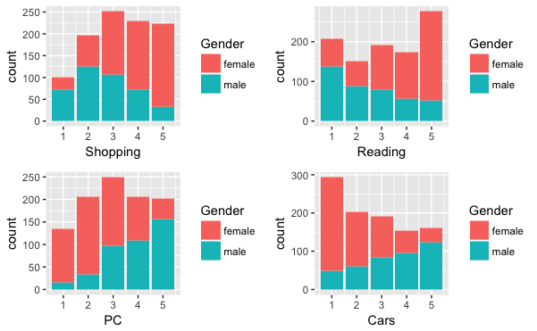

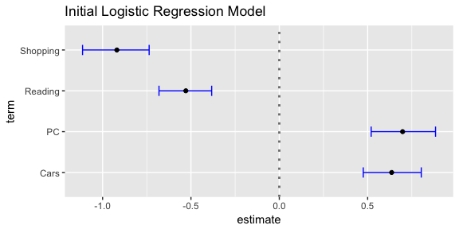

some notes about some of the caret measures: https://stats.stackexchange.com/questions/124001/what-is-the-intuition-behind-the-kappa-statistical-value-in-classification https://stats.stackexchange.com/questions/316641/what-is-the-usefulness-of-detection-rate-in-a-confusion-matrix

#### follow up models:

#### Random Forest

```r
Tree <- train(
  Gender ~ .,
  tuneLength = 10,
  importance = "impurity",
  data = interests, method = "ranger",
  trControl = myControl)
```

```
The metric "Accuracy" was not in the result set. ROC will be used instead.
```

```r
pred(Tree)
```

```
Confusion Matrix and Statistics

          Reference
Prediction female male
    female     89    6
    male       25   56

               Accuracy : 0.8239
                 95% CI : (0.7594, 0.8771)
    No Information Rate : 0.6477
    P-Value [Acc > NIR] : 1.948e-07

                  Kappa : 0.6392
 Mcnemar's Test P-Value : 0.001225

            Sensitivity : 0.7807
            Specificity : 0.9032
         Pos Pred Value : 0.9368
         Neg Pred Value : 0.6914
             Prevalence : 0.6477
         Detection Rate : 0.5057
   Detection Prevalence : 0.5398
      Balanced Accuracy : 0.8420

       'Positive' Class : female
```

```r
Tree
```

```
Random Forest

707 samples
 32 predictor
  2 classes: 'female', 'male'

No pre-processing
Resampling: Cross-Validated (10 fold)
Summary of sample sizes: 70, 71, 71, 71, 70, 71, ...
Resampling results across tuning parameters:

  mtry  splitrule   ROC        Sens       Spec
   2    gini        0.9019579  0.9472983  0.5930263
   2    extratrees  0.9060228  0.9659895  0.5257130
   5    gini        0.8981234  0.9254929  0.6412177
   5    extratrees  0.9054147  0.9431438  0.6153323
   8    gini        0.8894245  0.9093984  0.6531746
   8    extratrees  0.9029398  0.9340610  0.6336543
  12    gini        0.8859693  0.8971994  0.6607396
  12    extratrees  0.8979140  0.9244566  0.6495716
  15    gini        0.8839360  0.8888931  0.6698776
  15    extratrees  0.8953535  0.9177115  0.6471890
  18    gini        0.8783556  0.8852554  0.6611222
  18    extratrees  0.8941768  0.9130442  0.6551540
  22    gini        0.8755772  0.8862937  0.6579397
  22    extratrees  0.8915194  0.9075924  0.6579571
  25    gini        0.8732353  0.8826620  0.6583349
  25    extratrees  0.8880345  0.8992820  0.6627237
  28    gini        0.8707506  0.8756517  0.6623142
  28    extratrees  0.8874230  0.9049943  0.6491826
  32    gini        0.8660328  0.8751316  0.6531430
  32    extratrees  0.8835581  0.9003196  0.6507699

ROC was used to select the optimal model using  the largest value.
The final values used for the model were mtry = 2 and splitrule = extratrees.
```

# as far as tree based methods go it seems that extra trees is doing really well.

https://www.quora.com/What-is-the-extra-trees-algorithm-in-machine-learning

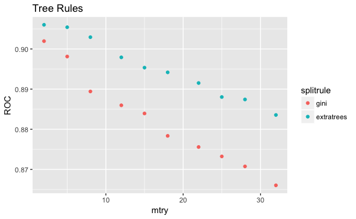

```r
treeinfo = as.data.frame(Tree$results)
ggplot(treeinfo, aes(mtry, ROC, color = splitrule))+
         geom_point()+
        ggtitle("Tree Rules")
```

```r
IMP= function(model){
importance = as.data.frame(varImp(model)$importance) %>% add_rownames("Question")
#%>% mutate(Question = as.factor(Question))
importance = arrange(importance, desc(Overall)) %>% mutate(Question = as.factor(Question))
order = importance$Question
importance$Question = factor(importance$Question, levels = order)
return(importance)
}
```

```r
TreeImportant= IMP(Tree)
```

```
Deprecated, use tibble::rownames_to_column() instead.
```

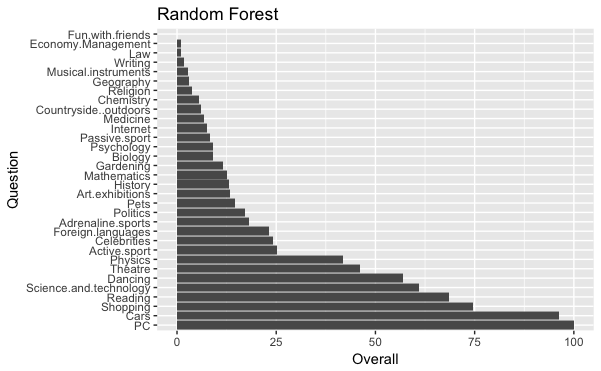

```r
implot= function(importance){
ggplot(importance, aes(Question, Overall))+
  geom_bar(stat = "identity")+
  coord_flip()}
a=TreeImportant %>% implot + ggtitle("Random Forest")
a
```

```r
logreg2 = train(Gender ~ Cars + PC + Shopping + Reading + Dancing, interests, method = 'glm',
              trControl = myControl)
```

```
The metric "Accuracy" was not in the result set. ROC will be used instead.
```

```r
pred(logreg2)
```

```
Confusion Matrix and Statistics

          Reference
Prediction female male
    female     79   16
    male       15   66

               Accuracy : 0.8239
                 95% CI : (0.7594, 0.8771)
    No Information Rate : 0.5341
    P-Value [Acc > NIR] : 6.558e-16

                  Kappa : 0.6458
 Mcnemar's Test P-Value : 1

            Sensitivity : 0.8404
            Specificity : 0.8049
         Pos Pred Value : 0.8316
         Neg Pred Value : 0.8148
             Prevalence : 0.5341
         Detection Rate : 0.4489
   Detection Prevalence : 0.5398
      Balanced Accuracy : 0.8227

       'Positive' Class : female
```

Notes of Caret Variable Importance: http://ftp.uni-bayreuth.de/math/statlib/R/CRAN/doc/vignettes/caret/caretVarImp.pdf

Here’s more info on the extra trees algorithm https://www.quora.com/What-is-the-extra-trees-algorithm-in-machine-learning ## What This is doing is crazy, this is really one of the best estimate of out of sample error possible with the data.

```r
library(lars)
ridge <- train(Gender ~., data = interests,
               method='glmnet',
               preProcess=c('scale', 'center'),
               trControl = myControl,
               tuneGrid = expand.grid(alpha = seq(.05, 1, length = 15),
                                               lambda = c((1:5)/10)))
```

[output not shown]

```r
ridgeImportance = IMP(ridge)
```

```
Deprecated, use tibble::rownames_to_column() instead.
```

```r
b=ridgeImportance %>% implot()+ ggtitle("Lasso Regression")
pred(ridge)
```

```
Confusion Matrix and Statistics

          Reference
Prediction female male
    female     89    6
    male       30   51

               Accuracy : 0.7955
                 95% CI : (0.7282, 0.8524)
    No Information Rate : 0.6761
    P-Value [Acc > NIR] : 0.0003082

                  Kappa : 0.5791
 Mcnemar's Test P-Value : 0.0001264

            Sensitivity : 0.7479
            Specificity : 0.8947
         Pos Pred Value : 0.9368
         Neg Pred Value : 0.6296
             Prevalence : 0.6761
         Detection Rate : 0.5057
   Detection Prevalence : 0.5398
      Balanced Accuracy : 0.8213

       'Positive' Class : female
```

```r
varImp(ridge, scale = F)
```

```
glmnet variable importance

  only 20 most important variables shown (out of 32)

                       Overall
PC                     0.18462
Cars                   0.18366
Shopping               0.16493
Reading                0.14266
Dancing                0.13354
Science.and.technology 0.13188
Theatre                0.11702
Physics                0.10774
Foreign.languages      0.08691
Celebrities            0.08230
Active.sport           0.08201
Politics               0.06654
History                0.06099
Adrenaline.sports      0.05136
Gardening              0.04806
Psychology             0.04581
Art.exhibitions        0.04381
Biology                0.03145
Pets                   0.02997
Internet               0.02136
```

```r
(ridge)
```

```
glmnet

707 samples
 32 predictor
  2 classes: 'female', 'male'

Pre-processing: scaled (32), centered (32)
Resampling: Cross-Validated (10 fold)
Summary of sample sizes: 70, 71, 71, 71, 70, 71, ...
Resampling results across tuning parameters:

  alpha      lambda  ROC        Sens       Spec
  0.0500000  0.1     0.9033815  0.8907086  0.73043224
  0.0500000  0.2     0.9088903  0.9138113  0.71330235
  0.0500000  0.3     0.9106913  0.9291293  0.68940745
  0.0500000  0.4     0.9112485  0.9361375  0.66272213
  0.0500000  0.5     0.9113762  0.9465204  0.63364953
  0.1178571  0.1     0.9040048  0.8951221  0.72724499
  0.1178571  0.2     0.9080473  0.9208209  0.69856763
  0.1178571  0.3     0.9079605  0.9340610  0.66590780
  0.1178571  0.4     0.9068599  0.9488594  0.61573389
  0.1178571  0.5     0.9050522  0.9623585  0.55957914
  0.1857143  0.1     0.9039414  0.8990182  0.72565136
  0.1857143  0.2     0.9054962  0.9218626  0.68263612
  0.1857143  0.3     0.9031857  0.9402967  0.62290362
  0.1857143  0.4     0.8991035  0.9595061  0.55042370
  0.1857143  0.5     0.8924408  0.9722266  0.44448397
  0.2535714  0.1     0.9027636  0.9018740  0.72007525
  0.2535714  0.2     0.9014377  0.9255010  0.65715550
  0.2535714  0.3     0.8954588  0.9491225  0.58108835
  0.2535714  0.4     0.8842053  0.9672976  0.45244577
  0.2535714  0.5     0.8665992  0.9844338  0.26684848
  0.3214286  0.1     0.9010280  0.9031768  0.71250395
  0.3214286  0.2     0.8963238  0.9252412  0.64043350
  0.3214286  0.3     0.8834367  0.9512031  0.51736546
  0.3214286  0.4     0.8624466  0.9761281  0.32061753
  0.3214286  0.5     0.8397704  0.9929971  0.08842882
  0.3892857  0.1     0.8986652  0.9026566  0.70374534
  0.3892857  0.2     0.8892737  0.9299145  0.61414501
  0.3892857  0.3     0.8678520  0.9571778  0.44487921
```

[output cut: 35 more lines]

```
  0.8642857  0.4     0.5000000  1.0000000  0.00000000
  0.8642857  0.5     0.5000000  1.0000000  0.00000000
  0.9321429  0.1     0.8677676  0.9037016  0.62329887
  0.9321429  0.2     0.7988687  0.9774356  0.14931386
  0.9321429  0.3     0.5255584  1.0000000  0.00000000
  0.9321429  0.4     0.5000000  1.0000000  0.00000000
  0.9321429  0.5     0.5000000  1.0000000  0.00000000
  1.0000000  0.1     0.8635804  0.9036996  0.60538007
  1.0000000  0.2     0.7817566  0.9828881  0.09398596
  1.0000000  0.3     0.5255584  1.0000000  0.00000000
  1.0000000  0.4     0.5000000  1.0000000  0.00000000
  1.0000000  0.5     0.5000000  1.0000000  0.00000000

ROC was used to select the optimal model using  the largest value.
The final values used for the model were alpha = 0.05 and lambda = 0.5.
```

## This is a really cool idea, these are scaled absolute value t-statistics. Were able to get some sort of way to compare what the two models are saying.

```r
fullmodel = train(Gender ~., data= interests, method = 'glm',
              trControl = myControl)
c=IMP(fullmodel) %>% implot() + ggtitle("Logistic Regression")
pred(fullmodel)
```

```
Confusion Matrix and Statistics

          Reference
Prediction female male
    female     83   12
    male       15   66

               Accuracy : 0.8466
                 95% CI : (0.7847, 0.8964)
    No Information Rate : 0.5568
    P-Value [Acc > NIR] : 2.278e-16

                  Kappa : 0.6904
 Mcnemar's Test P-Value : 0.7003

            Sensitivity : 0.8469
            Specificity : 0.8462
         Pos Pred Value : 0.8737
         Neg Pred Value : 0.8148
             Prevalence : 0.5568
         Detection Rate : 0.4716
   Detection Prevalence : 0.5398
      Balanced Accuracy : 0.8465

       'Positive' Class : female
```

```r
varImp(logreg, scale =FALSE )
```

```
glm variable importance

         Overall
Shopping   9.579
Cars       7.608
PC         7.524
Reading    6.966
```

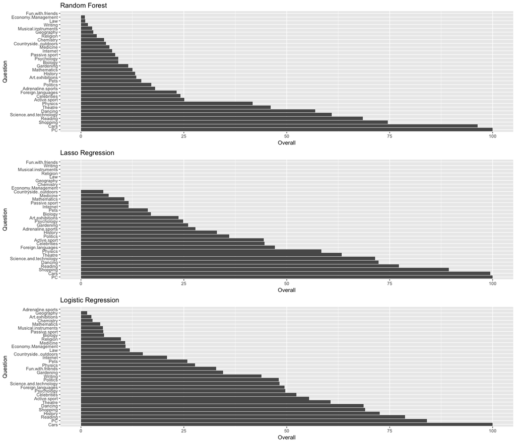

```r
library(gridExtra)
grid.arrange(a,b,c)
```